# **MATH 237 Project 2: Wine Color and Quality Analysis**

By: Amber Chatton

### Objectives:

This project investigates the main chemical and pysical properties that influence wine color and wine quality. Specifically, it examines how measurable chemical properties such as acidity, sugar content, sulfur compounds, density, and alcohol levels relate to whether a wine is classified as red or white, and how these same features influence wine quality ratings.

The analysis is split into two parts:

Part 1: Predicting Wine Color (Red vs. White)

Part 2: Predicting Wine Quality

Understanding these relationships is useful for wine producers, quality control specialists, and consumers interested in how measurable properties influence wine characteristics.

### Research Questions:

1. What features are the strongest determinate of wine color?
2. Does alcohol, sugar, and density have an effect on the color of wine?
3. Does color have an effect on the quality of the wine?
4. What features best determine what the quality of the wine is?

These questions guide the analysis throughout the project and frame the stages of data wrangling, exploratory data analysis, and modeling.

### Dataset Description:

The Wine Quality dataset from the UCI Machine Learning Repository includes two related datasets describing physicochemical properties and quality scores for red and white Vinho Verde wines from Portugal. Each row in the dataset corresponds to a wine sample characterized by 11 real-valued chemical measurements and one sensory quality score.

### Feature Descriptions

All input features are chemical characterstics that quantify various aspects of wine composition. The target variable for part 1 is the wine color, and a quality score assigned based on expert sensory evaluation for part 2.

Here is a description of each column:

`Fixed Acidity` — The amount of non-volatile acids present in the wine, which contribute to its structure and crispness. Higher values can indicate a “fuller” taste.

`Volatile Acidity` — The amount of acetic acid in wine. High volatile acidity is often associated with unpleasant vinegar-like taste.

`Citric Acid` — A weak organic acid that can add freshness and flavor, and can sometimes act as a preservative.

`Residual Sugar` — The amount of sugar remaining after fermentation. Higher residual sugar can lead to sweeter wine.

`Chlorides` — A measure of salt content. Higher levels may indicate greater salinity and can affect the balance of taste.

`Free Sulfur Dioxide` — Sulfur dioxide that is not bound to other compounds and can protect wine from microbial spoilage and oxidation.

`Total Sulfur Dioxide` — The sum of free and bound sulfur dioxide. Excessive sulfur dioxide can impact flavor.

`Density` — The mass per unit volume of wine. It is related to sugar and alcohol content.

`pH` — Acidity level of wine on a scale typically from 0 to 14 (lower pH indicates higher acidity).

`Sulphates` — Sulphate additives can contribute to wine stability and also influence the perception of flavor.

`Alcohol` — Alcohol content as a percentage of volume; a strong driver of wine quality as perceived by taste testers.

`Quality` (Output Variable for part 2) — Sensory quality score between 0 (very poor) and 10 (excellent) based on expert evaluation.

**Data Source:**  
UCI Machine Learning Repository Wine Quality Dataset https://archive.ics.uci.edu/dataset/186/wine+quality

Originally published by Cortez et al. (2009), this dataset was developed to model wine preferences using chemical analyses of Vinho Verde wines.

```python
# Import libraries
import pandas as pd
import numpy as np
import matplotlib.pyplot as plt
import seaborn as sns
from sklearn.linear_model import LogisticRegression
from sklearn.tree import DecisionTreeClassifier
from sklearn.model_selection import train_test_split
from sklearn.metrics import r2_score, mean_squared_error
from sklearn.metrics import accuracy_score
from sklearn.preprocessing import StandardScaler
from sklearn.pipeline import Pipeline
from sklearn.metrics import confusion_matrix
from sklearn.metrics import classification_report

# Setting up my polotting and visualization
plt.style.use('default')
sns.set_palette("husl")
plt.rcParams['figure.figsize'] = (10, 6)
plt.rcParams['font.size'] = 12

pd.set_option('display.width', 200)
```

# Part 1: Predicting Wine Color

## Step 1: Data Wrangling

## Step 2: Exploratory Data Analysis (EDA)

## Step 3: Predictive Modeling

## Step 4: Model Selection and Evaluation

## Step 5: Ethical Concerns and Limitations

# Data Wrangling

**Part 1: Load the both datasets into Python**

**Part 2: Create "color" column and combine datasets**

**Part 3: Check for missing values and handle them (ifany)**

**Part 4: Handle any data type conversions**

### Part 1 : Load the dataset into Python

```python
# Part 1 : Load the dataset into Python

# Connect to Google Drive
from google.colab import drive
drive.mount('/content/drive')

red = pd.read_csv('/content/drive/My Drive/Math237Fall25/Datasets/winequality-red.csv', sep=';')
white = pd.read_csv('/content/drive/My Drive/Math237Fall25/Datasets/winequality-white.csv', sep=';')
```

### Part 2: Create "color" column and combine datasets

This step creates a binary color indicator and merges the red and white wine datasets into a single combined dataset for analysis.

```python
# Create a new column named "color" in each dataset
red['color'] = 1
white['color'] = 0

# Combine the two datasets together to make one called "wine"
wine = pd.concat([red, white], axis=0).reset_index(drop=True)

print("Dataset shape:", wine.shape)
wine.head()
```

```
Dataset shape: (6497, 13)
```

|  | fixed acidity | volatile acidity | citric acid | residual sugar | chlorides | free sulfur dioxide | total sulfur dioxide | density | pH | sulphates | alcohol | quality | color |
| --- | --- | --- | --- | --- | --- | --- | --- | --- | --- | --- | --- | --- | --- |
| 0 | 7.4 | 0.70 | 0.00 | 1.9 | 0.076 | 11.0 | 34.0 | 0.9978 | 3.51 | 0.56 | 9.4 | 5 | 1 |
| 1 | 7.8 | 0.88 | 0.00 | 2.6 | 0.098 | 25.0 | 67.0 | 0.9968 | 3.20 | 0.68 | 9.8 | 5 | 1 |
| 2 | 7.8 | 0.76 | 0.04 | 2.3 | 0.092 | 15.0 | 54.0 | 0.9970 | 3.26 | 0.65 | 9.8 | 5 | 1 |
| 3 | 11.2 | 0.28 | 0.56 | 1.9 | 0.075 | 17.0 | 60.0 | 0.9980 | 3.16 | 0.58 | 9.8 | 6 | 1 |
| 4 | 7.4 | 0.70 | 0.00 | 1.9 | 0.076 | 11.0 | 34.0 | 0.9978 | 3.51 | 0.56 | 9.4 | 5 | 1 |

After reviewing all features in the Wine Quality dataset, it is determined that every variable directly relates to at least one of the above research questions regarding wine color and wine quality. All features in the dataset represent physical and chemical measurments. These properties are precisely the characteristics that differentiate red and white wines and influence expert quality ratings.

Because all features are conceptually tied to wine composition, classification, and evaluation, the full set of features was retained to ensure a comprehensive analysis of how these properties relate to wine color and wine quality.

Retaining all features allows the models to fully capture the chemical differences between wines while remaining aligned with the project objectives.

### Part 3: Check for missing values and handle them (if any)

To Properly manage missing data, it is important to first examine it. Identify what is missing and consider possible reasons for these missing values.

```python
# Check for missing data
print("Columns with missing values:\n")
missing_counts = wine.isnull().sum()
missing_counts = missing_counts[missing_counts > 0] # Only show columns that have missing values
print(missing_counts)
wine.info()
```

```
Columns with missing values:

Series([], dtype: int64)
<class 'pandas.core.frame.DataFrame'>
RangeIndex: 6497 entries, 0 to 6496
Data columns (total 13 columns):
 #   Column                Non-Null Count  Dtype
---  ------                --------------  -----
 0   fixed acidity         6497 non-null   float64
 1   volatile acidity      6497 non-null   float64
 2   citric acid           6497 non-null   float64
 3   residual sugar        6497 non-null   float64
 4   chlorides             6497 non-null   float64
 5   free sulfur dioxide   6497 non-null   float64
 6   total sulfur dioxide  6497 non-null   float64
 7   density               6497 non-null   float64
 8   pH                    6497 non-null   float64
 9   sulphates             6497 non-null   float64
 10  alcohol               6497 non-null   float64
 11  quality               6497 non-null   int64
 12  color                 6497 non-null   int64
dtypes: float64(11), int64(2)
memory usage: 660.0 KB
```

After checking for missing values across all features, the dataset returned back no missing values. This meaning every observation has complete information for each measurable chemical property and the quality score.

Since there are no missing values, no imputation or row removal was required before proceeding with exploratory data analysis or modeling.

### Part 4: Handle any data type conversions

Upon inspection, it is determined all features are already stored using appropriate numeric data types. The chemical measurements are represented as continuous numerical values, which is suitable for correlation analysis, visualization, and model training.

The target variables are stored as integers:

quality is an integer score, which is appropriate for classification or threshold-based modeling.

color is a binary indicator (0 = white, 1 = red), correctly stored as int64 for classification tasks.

Because all features and targets are already numeric and correctly typed, no data type conversions were necessary before proceeding with EDA or modeling.

# Exploratory Data Analysis (EDA)

**Part 1: Use simple plots like box plots and scatter plots**

**Part 2: Look at correlations between features and color**

**Part 3: Look into if its better to create ratio features based on correlation**

### Part 1 : Use simple plots like box plots and scatter plots

To visually examine how each chemical feature differs between red and white wines, box plots were created for all numeric features grouped by wine color.

Before any feature engineering or modeling, these plots help identify which features show strong separation between red and white wines and which features have similar distributions across both groups.

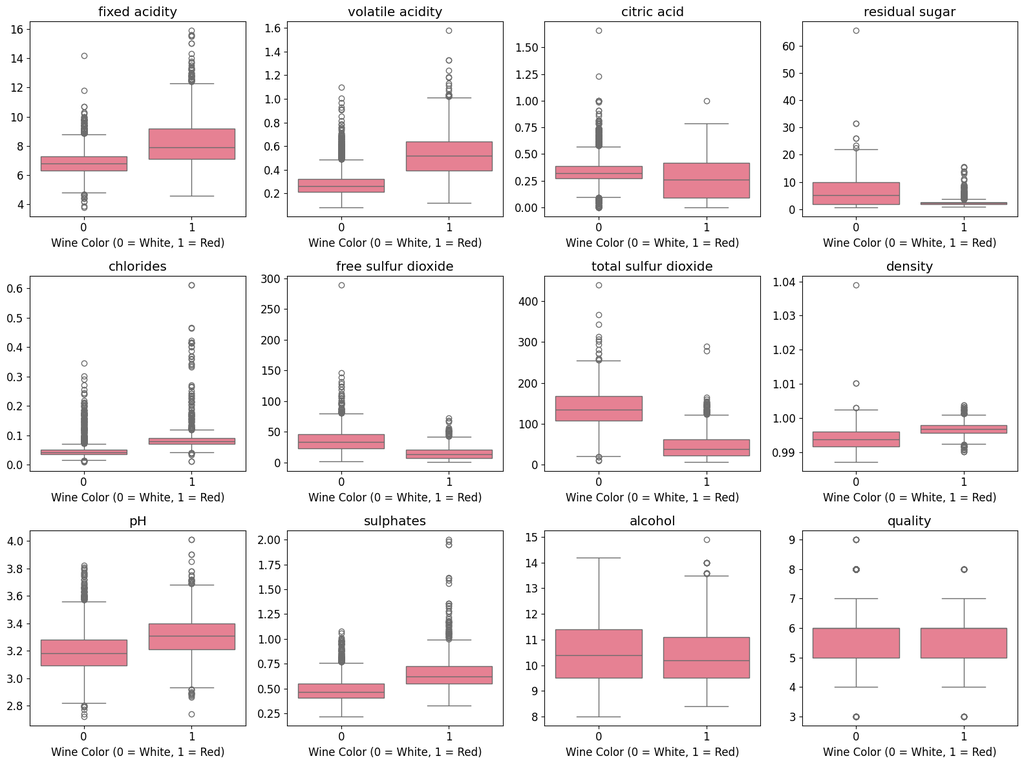

```python
features = wine.drop(columns=['color']).columns
n_features = len(features)
n_cols = 4
n_rows = int(np.ceil(n_features / n_cols))

fig, axes = plt.subplots(n_rows, n_cols, figsize=(16, 4 * n_rows))
axes = axes.flatten()

for i, feature in enumerate(features):
    sns.boxplot(
        x='color',
        y=feature,
        data=wine,
        ax=axes[i]
    )
    axes[i].set_title(feature)
    axes[i].set_xlabel("Wine Color (0 = White, 1 = Red)")
    axes[i].set_ylabel("")

for j in range(i + 1, len(axes)):
    fig.delaxes(axes[j])

plt.tight_layout()
plt.show()
```

Several features show clear separation between red and white wines, indicating strong relationships with wine color.

**Acidity Measures**

- `Fixed acidity` and `volatile acidity` are both noticeably higher in red wines than in white wines.
- Red wines show higher medians and wider interquartile ranges, particularly for `volatile acidity`, suggesting that acidity composition differs meaningfully by color.
- `Citric acid` displays overlap between groups, but white wines tend to have slightly higher median values, indicating it may contribute to color differentiation in combination with other features rather than on its own.

**Sulfur Compounds**

- `Free sulfur dioxide` and total `sulfur dioxide` show some of the strongest visual separation.
- White wines have much higher median values and greater variability for both measures.
- This strong difference suggests sulfur-related features are highly informative for predicting wine color.

**Chlorides and Sulphates**

- `Chlorides` are slightly higher in red wines, though there is overlap between groups.
- `Sulphates` show a clearer distinction, with red wines having higher median values and a wider distribution. This suggests sulphates may play a role in differentiating wine color.

**pH and Alcohol**

- `pH` values are slightly higher for red wines, though distributions overlap considerably, indicating `pH` alone may not strongly separate wine color.
- `Alcohol` shows very similar distributions for both wine types, with substantial overlap, suggesting alcohol content is not a primary driver of wine color differences.

**Quality**

The `quality` feature shows nearly identical distributions for red and white wines, indicating that wine color alone does not determine quality scores. This supports the need to model quality separately from color in Part 2 of the project.

**Summary**

Overall, the box plots reveal that features related to sulfur content, acidity, residual sugar, sulphates, and density show the most pronounced differences between red and white wines. These features are likely to be important predictors in the wine color classification model. In contrast, alcohol and quality exhibit substantial overlap and appear less informative for distinguishing wine color on their own.

After examining box plots, scatter plots are used to further explore how individual chemical features relate to wine color and how they interact with one another. These plots focus on features that showed noticeable separation between red and white wines in earlier analysis and are commonly discussed in wine chemistry.

**Alcohol vs Density**

Alcohol and density have a known inverse relationship in wine chemistry, making this pairing useful for distinguishing red and white wines.

**Residual Sugar vs Density**

Residual sugar directly affects density, especially in white wines, which often have higher sugar content.

**Volatile Acidity vs Citric Acid**

These two acidity measures help illustrate chemical balance differences between red and white wines.

**Alcohol vs Sulphates**

Sulphates contribute to wine stability and flavor and may interact differently with alcohol content across wine types.

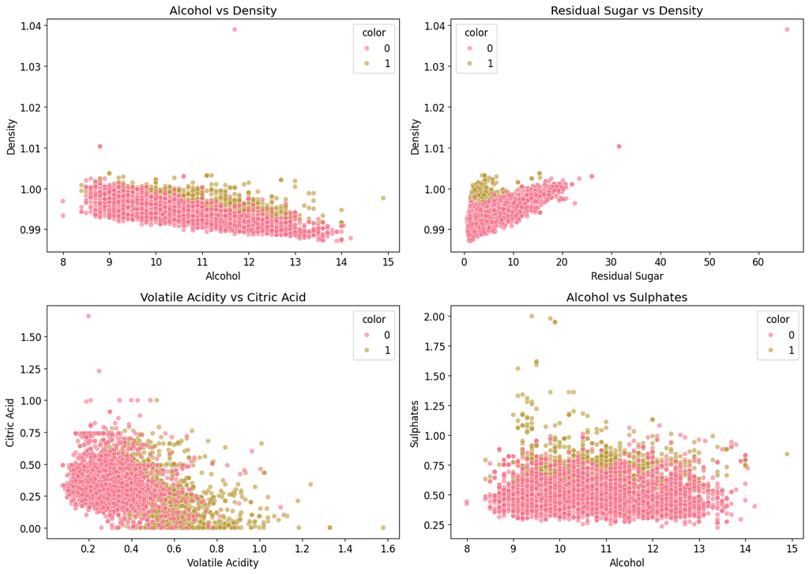

```python
# Set up 2x2 grid
fig, axes = plt.subplots(2, 2, figsize=(14, 10))

# Alcohol vs Density
sns.scatterplot(
    data=wine,
    x='alcohol',
    y='density',
    hue='color',
    alpha=0.6,
    ax=axes[0, 0]
)
axes[0, 0].set_title("Alcohol vs Density")

# Residual Sugar vs Density
sns.scatterplot(
    data=wine,
    x='residual sugar',
    y='density',
    hue='color',
    alpha=0.6,
    ax=axes[0, 1]
)
axes[0, 1].set_title("Residual Sugar vs Density")

# Volatile Acidity vs Citric Acid
sns.scatterplot(
    data=wine,
    x='volatile acidity',
    y='citric acid',
    hue='color',
    alpha=0.6,
    ax=axes[1, 0]
)
axes[1, 0].set_title("Volatile Acidity vs Citric Acid")

# Alcohol vs Sulphates
sns.scatterplot(
    data=wine,
    x='alcohol',
    y='sulphates',
    hue='color',
    alpha=0.6,
    ax=axes[1, 1]
)
axes[1, 1].set_title("Alcohol vs Sulphates")

for ax in axes.flat:
    ax.set_xlabel(ax.get_xlabel().title())
    ax.set_ylabel(ax.get_ylabel().title())

plt.tight_layout()
plt.show()
```

These scatter plots examine relationships between key chemical features and how they differ by wine color (0 = white, 1 = red). The patterns observed help explain which features are most useful for distinguishing wine color.

**Residual Sugar vs. Density**

A strong positive relationship is observed between residual sugar and density. Wines with higher residual sugar tend to have higher density. White wines show a much wider range of residual sugar values, including several high-sugar outliers, whereas red wines are more tightly clustered at lower sugar levels. This clear separation indicates that residual sugar plays a major role in distinguishing white wines from red wines and reinforces its usefulness as a predictor of wine color.

**Volatile Acidity vs. Citric Acid**

An inverse relationship is visible between volatile acidity and citric acid. As volatile acidity increases, citric acid tends to decrease. Red wines generally exhibit higher volatile acidity and lower citric acid values, while white wines are more concentrated at lower volatile acidity and higher citric acid levels. This contrast highlights fundamental chemical differences between red and white wines and supports the inclusion of both variables in color prediction models.

**Summary**

Across all four scatter plots, combinations involving density, residual sugar, alcohol, volatile acidity, and citric acid show the clearest separation between red and white wines. The scatter plots complement the box plot analysis by illustrating how feature interactions, rather than individual features alone, contribute to differences in wine color.

### Part 2: Look at correlations between features and color

A correlation matrix is computed using all numeric variables, including the binary color variable. This allows direct comparison between each feature and wine color, as well as relationships among features themselves.

To improve interpretability, correlations were evaluated using their absolute values, allowing strong relationships to be identified regardless of direction.

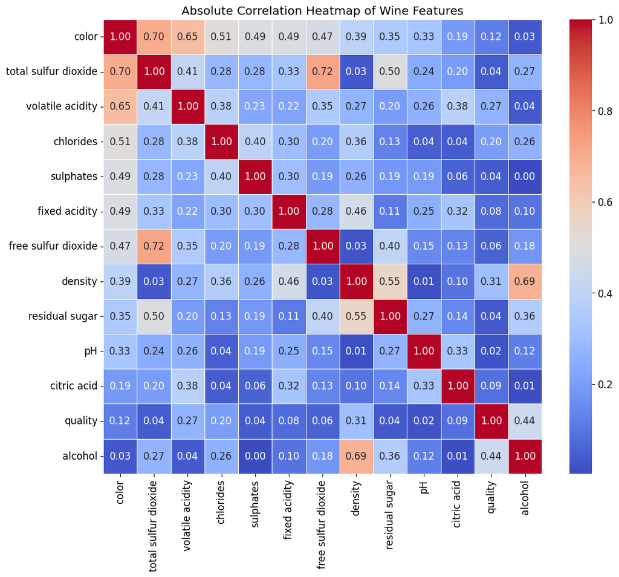

```python
# Compute correlation matrix
corr = wine.corr(numeric_only=True)

# Convert correlations to absolute values
corr_abs = corr.abs()

# Sort features by absolute correlation with color
sorted_features = corr_abs['color'].sort_values(ascending=False).index

# Reorder correlation matrix rows AND columns
corr_abs_sorted = corr_abs.loc[sorted_features, sorted_features]

# Create heatmap with values inside boxes
plt.figure(figsize=(12, 10))
sns.heatmap(
    corr_abs_sorted,
    cmap='coolwarm',
    annot=True,
    fmt=".2f",
    linewidths=0.5
)

plt.title("Absolute Correlation Heatmap of Wine Features")
plt.show()
```

```python
# Compute correlation matrix
corr = wine.corr(numeric_only=True)

# Extract correlations with color
color_corr = corr['color'].drop('color')

# Use absolute values and sort descending
color_corr_abs = color_corr.abs().sort_values(ascending=False)

# Filter for strong correlations (|r| ≥ 0.7)
strong_color_corr = color_corr_abs[color_corr_abs >= 0.7]

strong_color_corr
```

|  | color |
| --- | --- |
| total sulfur dioxide | 0.700357 |

**dtype:** float64

**Correlation Summary**

The correlation analysis shows that wine color is strongly associated with several chemical features, indicating that red and white wines differ systematically in their composition.

The strongest relationship with wine color is observed for `total sulfur dioxide` (|r| ≈ 0.70), followed closely by `volatile acidity` (|r| ≈ 0.65) and `chlorides` (|r| ≈ 0.51). These results suggest that sulfur related compounds and acidity play a major role in distinguishing red and white wines. `Free sulfur dioxide`, `fixed acidity`, and `sulphates` also show moderate correlations with color, further supporting the idea that preservation and acidity related properties differ by wine type.

Features such as `density`, `residual sugar`, and `pH` exhibit weaker to moderate correlations with wine color, indicating some separation between red and white wines but with greater overlap. In contrast, alcohol content shows almost no correlation with color, suggesting that alcohol level alone does not meaningfully differentiate red and white wines in this dataset.

Overall, the heatmap and filtered correlation results consistently indicate that sulfur compounds and acidity related features are the most informative variables for predicting wine color, while alcohol and quality have limited direct association with color.

### Part 3: Look into if its better to create ratio features based on correlation

At this point in the analysis, keeping all original features is appropriate, with feature engineering reserved for later model evaluation if needed.

# Predictive Modeling

**Part 1: Start with a classification model**

**Part 2: Train the model and make predictions**

### Part 1: Start with a classification model

### Part 2: Train the model and make predictions

Although logistic regression is a common classification method covered in this course, a decision tree classifier is used for predicting wine color in Part 1 of this project. This choice was made to explore an alternative classification approach and to take advantage of the interpretability of decision trees when modeling non linear relationships between features.

Wine color is influenced by complex interactions among chemical properties such as alcohol content, residual sugar, density, and sulfur compounds. A decision tree is well suited for this task because it can naturally capture non linear decision boundaries and interactions without requiring explicit feature transformations.

Additionally, logistic regression is reserved for Part 2: Predicting Wine Quality. Using a decision tree in Part 1 and logistic regression in Part 2 provides broader exposure to classification techniques.\

```python
# Define features and target

X = wine.drop(columns=['color'])
y = wine['color']

# Create train + validation and test split
X_temp, X_test, y_temp, y_test = train_test_split(
    X, y, test_size=0.2, random_state=42, stratify=y
)

# Create train and validation split

X_train, X_val, y_train, y_val = train_test_split(
    X_temp, y_temp, test_size=0.25, random_state=42, stratify=y_temp
)

# Pipeline: Scaling + Decision Tree
pipe_tree = Pipeline([
    ('scaler', StandardScaler()),   # kept for consistency
    ('tree', DecisionTreeClassifier(random_state=42))
])

# Train model
pipe_tree.fit(X_train, y_train)

# Predictions
y_train_pred = pipe_tree.predict(X_train)
y_val_pred = pipe_tree.predict(X_val)
y_test_pred = pipe_tree.predict(X_test)

# Accuracy
print("Training Accuracy:", accuracy_score(y_train, y_train_pred))
print("Validation Accuracy:", accuracy_score(y_val, y_val_pred))
print("Test Accuracy:", accuracy_score(y_test, y_test_pred))
```

```
Training Accuracy: 1.0
Validation Accuracy: 0.9769230769230769
Test Accuracy: 0.9869230769230769
```

Explanation of Model Performance

The decision tree model achieved a training accuracy of 1.0, meaning it classified every training observation correctly. This indicates that the model learned the training data extremely well. However, perfect training accuracy is also a warning sign, as decision trees are known to easily overfit by memorizing patterns in the training set rather than learning generalizable relationships.

Despite this, the validation accuracy (≈ 0.977) and test accuracy (≈ 0.987) remain very high and close to each other. The small difference between training, validation, and test accuracy suggests that although the tree fits the training data perfectly, it still generalizes well to unseen data in this case. This indicates that the chemical features in the dataset provide very strong separation between red and white wines.

This result aligns with expectations for this dataset, as red and white wines are chemically distinct, making wine color an easier classification task than predicting wine quality.

# Model Selection and Evaluation

**Part 1: Check the model performance, use a matrix to see the TP and FP**

**Part 2: Check for overfitting and Interpret the coefficients**

**Part 3: Use a classification report**

### Part 1: Check the model performance, use a matrix to see the TP and FP

After training the decision tree classifier, model performance is evaluated using a confusion matrix. This allows examination of true positives, true negatives, false positives, and false negatives, rather than relying only on accuracy. This is especially important for classification problems, as accuracy alone does not show where misclassifications occur.

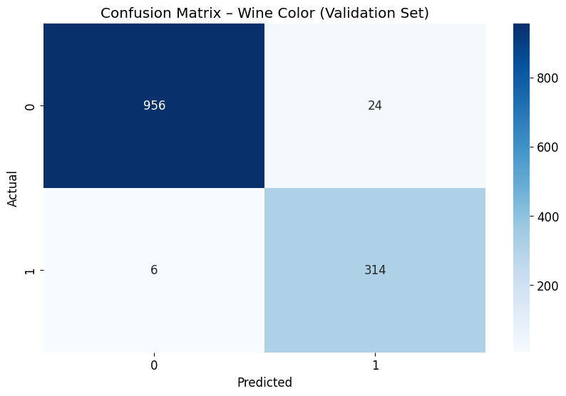

```python
cm_val = confusion_matrix(y_val, y_val_pred)

sns.heatmap(
    cm_val,
    annot=True,
    fmt='d',
    cmap='Blues'
)
plt.xlabel("Predicted")
plt.ylabel("Actual")
plt.title("Confusion Matrix – Wine Color (Validation Set)")
plt.show()
```

**Interpretation**

The confusion matrix shows that the model correctly classifies most red and white wines, with relatively few misclassifications. Most errors occur where wines with similar chemical properties are confused across color classes.

### Part 2: Check for overfitting and Interpret the coefficients

To check for overfitting, training, validation, and test accuracy are compared again.

```python
print("Training Accuracy:", accuracy_score(y_train, y_train_pred))
print("Validation Accuracy:", accuracy_score(y_val, y_val_pred))
print("Test Accuracy:", accuracy_score(y_test, y_test_pred))
```

```
Training Accuracy: 1.0
Validation Accuracy: 0.9769230769230769
Test Accuracy: 0.9869230769230769
```

**Interpretation**

The decision tree achieves perfect accuracy on the training set, which indicates that the model fits the training data extremely well. The slightly lower but still high validation and test accuracy suggests mild overfitting, which is expected behavior for decision trees. However, because validation and test performance remain high and close to each other, the model still generalizes well to unseen data.

**Why Coefficients Are Not Interpreted**

Decision trees do not have coefficients that directly quantify feature effects. Instead, they make decisions through hierarchical splits. For this reason, coefficient interpretation is not applicable for this model, and interpretability is handled through performance metrics rather than parameter values.

### Part 3: Use a classification report

Accuracy alone can be misleading, especially in classification problems where one class may be easier to predict than another. The classification report provides a more detailed evaluation.

```python
print(classification_report(y_val, y_val_pred))
```

```
              precision    recall  f1-score   support

           0       0.99      0.98      0.98       980
           1       0.93      0.98      0.95       320

    accuracy                           0.98      1300
   macro avg       0.96      0.98      0.97      1300
weighted avg       0.98      0.98      0.98      1300
```

**Interpretation of the Classification Report**

The classification report summarizes the model’s performance for each wine color class using precision, recall, and F1-score, providing a more detailed evaluation than accuracy alone.

**Class 0 (White Wine):**

- Precision of 0.99 indicates that when the model predicts a wine as white, it is correct 99% of the time.
- Recall of 0.98 shows that the model successfully identifies nearly all white wines in the dataset.
- The high F1-score (0.98) reflects a strong balance between precision and recall for this class.

**Class 1 (Red Wine):**

- Precision of 0.93 means that some wines predicted as red are actually white, though the majority are correct.
- Recall of 0.98 indicates that the model correctly identifies almost all red wines.
- The F1-score of 0.95 suggests strong overall performance, with slightly more confusion compared to white wines.

**Overall Performance:**

The overall accuracy of 0.98 confirms that the model correctly classifies most wines.

The macro average treats both classes equally and shows consistently high performance across classes.

The weighted average accounts for class imbalance and further confirms that the model performs well across the entire dataset.

Overall, the classification report shows that the model distinguishes red and white wines extremely well, with particularly strong recall for both classes. Minor misclassification occurs primarily when predicting red wines, but the performance remains consistently high across all evaluation metrics.

# Ethical Concerns and Limitations

**Try and find any biases in the dat**

### Potential Biases in the Data

Several potential sources of bias and limitation exist within the Wine Quality dataset that should be considered when interpreting the results.

- Regional Bias: All wine samples come exclusively from the Vinho Verde region of Portugal. Because red and white wines from this region may follow specific production practices, the chemical differences used to distinguish wine color may not generalize to wines produced in other regions, climates, or winemaking traditions.
- Class Imbalance (Color): The dataset contains substantially more white wine samples than red wine samples. This imbalance can influence classification performance, potentially making the model more sensitive to patterns common in white wines. Although stratified sampling helps reduce this issue, class imbalance may still affect evaluation metrics.
- Chemical Only Features: Wine color is predicted solely using laboratory-measured chemical properties. While these measurements are objective, they do not include visual characteristics or production details that may also influence wine color classification in real-world settings.

# Final Summary: Part 1 Predicting Wine Color

This section focuses on identifying the chemical characteristics that distinguish red wines from white wines. Using exploratory data analysis, correlation analysis, and classification modeling, the relationship between physical and chemical features and wine color is examined. The results from this analysis are used to answer the first two research questions related to wine color.

### 1. What are the strongest determinants of wine color?

The analysis shows that several chemical features are strongly associated with whether a wine is classified as red or white. Based on the box plots, scatter plots, correlation heatmap, and classification model results, the most influential features include:

`Total sulfur dioxide`: This feature shows the strongest correlation with wine color. White wines consistently have much higher total sulfur dioxide levels, reflecting common preservation practices in white wine production.

`Volatile acidity`: Red wines tend to exhibit higher volatile acidity, which contributes to noticeable separation between wine colors.

`Chlorides and sulphates`: These features are generally higher in red wines and show moderate to strong relationships with color, suggesting differences in mineral and additive composition.

Overall, sulfur-related compounds, acidity measures, and sugar/density relationships emerge as the most important determinants of wine color.

### 2. Does alcohol, sugar, and density have an effect on the color of wine?

Yes. Exploratory analysis indicates that residual sugar and density have a clear and meaningful effect on wine color, while alcohol plays a more indirect role.

`Residual sugar` shows a strong positive relationship with density and is substantially higher in white wines. White wines also exhibit a much wider range of sugar values, including high-sugar outliers, which clearly separates them from red wines.

`Alcohol` displays a strong inverse relationship with density, but its direct relationship with wine color is weak. Alcohol distributions overlap heavily between red and white wines, indicating that alcohol alone does not strongly determine wine color.

Together, these results suggest that sugar and density are key contributors to wine color differences, while alcohol primarily influences color indirectly through its relationship with density rather than acting as a primary distinguishing factor.

# Part 2: Predicting Wine Quality

This section focuses on identifying the chemical characteristics that influence wine quality. Unlike Part 1, which examined differences between red and white wines, this section models quality directly using chemical features.

## Step 1: Data Wrangling

## Step 2: Exploratory Data Analysis (EDA)

## Step 3: Predictive Modeling

## Step 4: Model Selection and Evaluation

## Step 5: Ethical Concerns and Limitations

# Data Wrangling

**Part 1: Seperate the datasets into two based on color**

**Part 2: Create Binary Quality Target**

**Part 3: Check for missing values and handle them (ifany)**

**Part 4: Handle any data type conversions**

### Part 1: Seperate the datasets into two based on color

The combined dataset used in Part 1 is separated back into red and white wine subsets. This step ensures that wine quality can be analyzed within a consistent wine type rather than across fundamentally different wine categories. Because red and white wines differ chemically, modeling quality within a single color avoids confounding effects caused by color related differences.

The red wine dataset is used for the primary quality analysis, consistent with common usage of the Wine Quality dataset in classification tasks.

```python
# Separate the dataset back into red and white wines
red_wine = wine[wine['color'] == 1].copy()
white_wine = wine[wine['color'] == 0].copy()

print("Red wine shape:", red_wine.shape)
print("White wine shape:", white_wine.shape)
```

```
Red wine shape: (1599, 13)
White wine shape: (4898, 13)
```

### Part 2: Create Binary Quality Target

Wine quality scores are converted into a binary target variable to support logistic regression. Wines with a quality score of 7 or higher are labeled as high quality. Scores of 7 and above are generally considered “good to excellent” wines, while scores below 7 represent average to lower-quality wines. This creates a clear and interpretable distinction between higher-quality and lower-quality samples.

```python
# Create binary quality target
red_wine['high_quality'] = (red_wine['quality'] >= 7).astype(int)
white_wine['high_quality'] = (white_wine['quality'] >= 7).astype(int)

red_wine[['quality', 'high_quality']].head()
```

|  | quality | high_quality |
| --- | --- | --- |
| 0 | 5 | 0 |
| 1 | 5 | 0 |
| 2 | 5 | 0 |
| 3 | 6 | 0 |
| 4 | 5 | 0 |

### Part 3: Check for missing values and handle them (if any)

To Properly manage missing data, it is important to first examine it. Identify what is missing and consider possible reasons for these missing values.

```python
print("Missing values in red wine dataset:")
print(red_wine.isnull().sum())

print("\nMissing values in white wine dataset:")
print(white_wine.isnull().sum())
```

```
Missing values in red wine dataset:
fixed acidity           0
volatile acidity        0
citric acid             0
residual sugar          0
chlorides               0
free sulfur dioxide     0
total sulfur dioxide    0
density                 0
pH                      0
sulphates               0
alcohol                 0
quality                 0
color                   0
high_quality            0
dtype: int64

Missing values in white wine dataset:
fixed acidity           0
volatile acidity        0
citric acid             0
residual sugar          0
chlorides               0
free sulfur dioxide     0
total sulfur dioxide    0
density                 0
pH                      0
sulphates               0
alcohol                 0
quality                 0
color                   0
high_quality            0
dtype: int64
```

After checking for missing values across all features, the dataset returned back no missing values. This meaning every observation has complete information for each measurable chemical property and the quality score.

Since there are no missing values, no imputation or row removal was required before proceeding with exploratory data analysis or modeling.

### Part 4: Handle any data type conversions

Upon inspection, it is determined all features are already stored using appropriate numeric data types. The chemical measurements are represented as continuous numerical values, which is suitable for correlation analysis, visualization, and model training.

# Exploratory Data Analysis (EDA)

**Part 1: Use simple plots like box plots and scatter plots**

**Part 2: Look at correlations between features and quality**

**Part 3: Look into if its better to create ratio features based on correlation**

### Part 1 : Use simple plots like box plots and scatter plots

Simple plots such as box plots and scatter plots are used to examine how chemical features differ between lower- and higher-quality wines. These plots provide an initial understanding of which features show noticeable separation between quality groups and which exhibit substantial overlap.

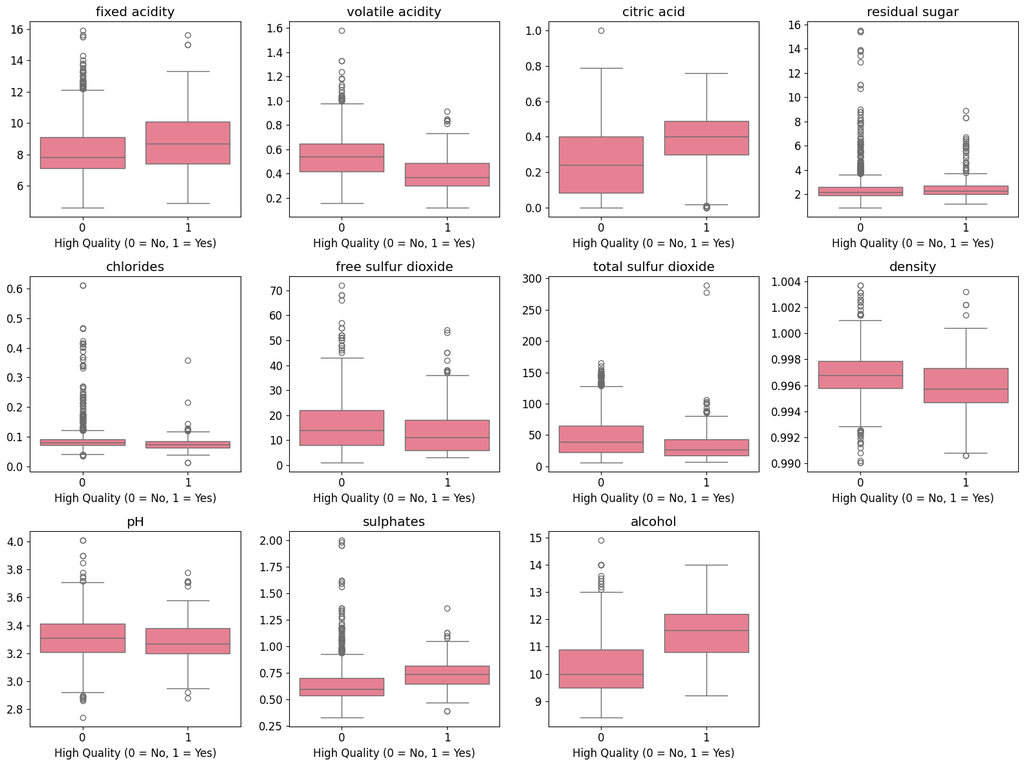

```python
features_q = red_wine.drop(columns=['quality', 'high_quality', 'color']).columns

n_features = len(features_q)
n_cols = 4
n_rows = int(np.ceil(n_features / n_cols))

fig, axes = plt.subplots(n_rows, n_cols, figsize=(16, 4 * n_rows))
axes = axes.flatten()

for i, feature in enumerate(features_q):
    sns.boxplot(
        x='high_quality',
        y=feature,
        data=red_wine,
        ax=axes[i]
    )
    axes[i].set_title(feature)
    axes[i].set_xlabel("High Quality (0 = No, 1 = Yes)")
    axes[i].set_ylabel("")

for j in range(i + 1, len(axes)):
    fig.delaxes(axes[j])

plt.tight_layout()
plt.show()
```

**Interpretation of Box Plots: Wine Quality**

The box plots compare the distributions of chemical features between lower-quality wines (0) and higher-quality wines (1). These visualizations help identify which features show meaningful separation between quality groups and are therefore likely to be informative predictors in the classification model.

`Alcohol` shows one of the clearest separations between quality groups. Higher-quality wines consistently have higher median alcohol levels and a distribution shifted upward relative to lower-quality wines. This suggests that alcohol content is a strong positive indicator of wine quality and is likely to play an important role in the quality prediction model.

`Sulphates` also show noticeable separation. Higher-quality wines tend to have slightly higher median sulphate values and a tighter distribution. This pattern suggests that sulphates, which contribute to wine stability and preservation, may be associated with better perceived quality.

`Density` shows a small but consistent difference, with higher-quality wines generally having slightly lower density. This aligns with the relationship between alcohol and density, as wines with higher alcohol content tend to be less dense. While the separation is not extreme, density appears to contribute useful information when considered alongside other features.

`Volatile acidity` exhibits a clear inverse relationship with quality. Higher-quality wines tend to have lower volatile acidity, while lower-quality wines show higher medians and greater spread. This is consistent with wine chemistry, as excessive volatile acidity is often associated with undesirable flavors.

`Citric acid` shows moderate separation, with higher-quality wines having slightly higher median values. While there is overlap between groups, the upward shift for higher-quality wines suggests citric acid may contribute positively to quality when combined with other acidity measures.

`Fixed acidity` shows some separation, with higher-quality wines tending toward higher median values, though the overlap between groups is substantial. This indicates that fixed acidity alone is not a strong discriminator but may still provide supportive information in combination with other features.

`Residual sugar` shows minimal separation between quality groups, with heavily overlapping distributions. This suggests that residual sugar is not a strong standalone predictor of quality in this dataset.

`Chlorides` exhibit slight differences between groups, with lower-quality wines tending toward higher values, but the overlap remains large. This feature may contribute marginally but is unlikely to be a dominant predictor on its own.

Both `sulfur dioxide` measures show some separation, with lower-quality wines generally having higher median values. However, variability is high, and the distributions overlap substantially. These features may still provide useful information when combined with other chemical properties.

`pH` values show very similar distributions across quality groups, indicating little direct relationship with wine quality. pH alone does not appear to strongly differentiate higher- and lower-quality wines.

Overall, the box plots indicate that alcohol, volatile acidity, sulphates, and density show the most meaningful differences between lower- and higher-quality wines. These features are likely to be the strongest contributors to the wine quality classification model. Other features, such as residual sugar and pH, show substantial overlap and appear less informative on their own but may still add value in combination with more predictive variables.

Scatter Plot Analysis: Wine Quality

After examining box plots comparing chemical features across high-quality and low-quality wines, scatter plots are used to further explore relationships between key features and wine quality. While box plots show distributional differences, scatter plots help visualize how features interact with each other and whether certain combinations are associated with higher quality ratings.

The scatter plots focus on features that showed noticeable differences in the box plot analysis.

The following pairings are most appropriate for answering the wine quality questions:

**Alcohol vs Quality** Alcohol consistently showed higher median values for high-quality wines in the box plots, making it a primary feature to examine directly against quality.

**Alcohol vs Density** Alcohol and density have a known inverse relationship. Since higher-quality wines tend to have higher alcohol and lower density, this pairing helps visualize that relationship.

**Volatile Acidity vs Citric Acid** These two acidity measures showed opposite trends for higher-quality wines, suggesting that their interaction may influence perceived quality.

**Sulphates vs Alcohol** Sulphates are associated with wine stability and flavor intensity and may amplify the effect of alcohol on quality.

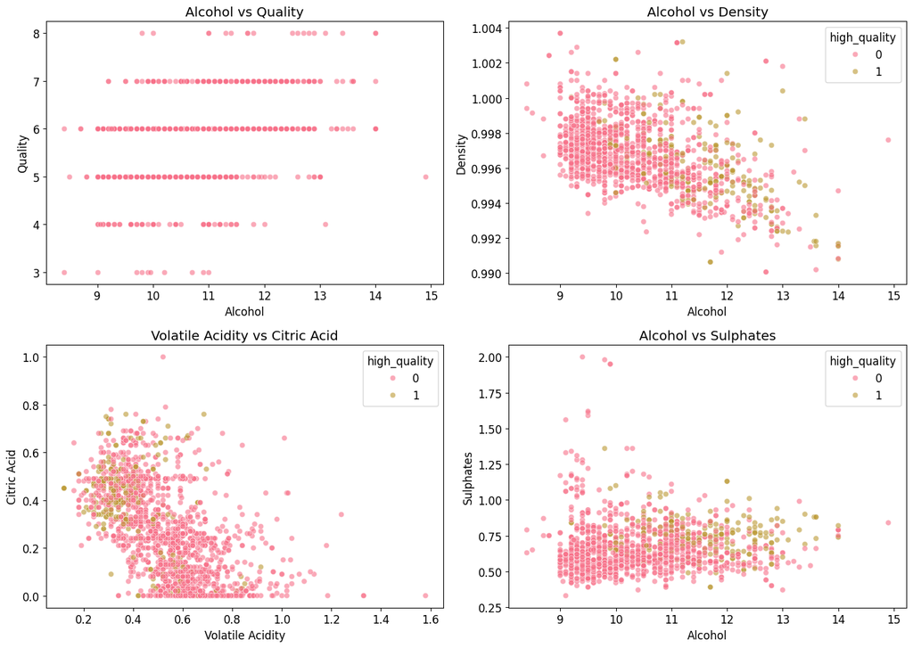

```python
# Set up 2x2 grid
fig, axes = plt.subplots(2, 2, figsize=(14, 10))

# Alcohol vs Quality
sns.scatterplot(
    data=red_wine,
    x='alcohol',
    y='quality',
    alpha=0.6,
    ax=axes[0, 0]
)
axes[0, 0].set_title("Alcohol vs Quality")

# Alcohol vs Density
sns.scatterplot(
    data=red_wine,
    x='alcohol',
    y='density',
    hue='high_quality',
    alpha=0.6,
    ax=axes[0, 1]
)
axes[0, 1].set_title("Alcohol vs Density")

# Volatile Acidity vs Citric Acid
sns.scatterplot(
    data=red_wine,
    x='volatile acidity',
    y='citric acid',
    hue='high_quality',
    alpha=0.6,
    ax=axes[1, 0]
)
axes[1, 0].set_title("Volatile Acidity vs Citric Acid")

# Sulphates vs Alcohol
sns.scatterplot(
    data=red_wine,
    x='alcohol',
    y='sulphates',
    hue='high_quality',
    alpha=0.6,
    ax=axes[1, 1]
)
axes[1, 1].set_title("Alcohol vs Sulphates")

for ax in axes.flat:
    ax.set_xlabel(ax.get_xlabel().title())
    ax.set_ylabel(ax.get_ylabel().title())

plt.tight_layout()
plt.show()
```

**Alcohol vs. Quality**

Alcohol content shows a positive relationship with wine quality. Higher quality wines are more frequently observed at higher alcohol levels, particularly above approximately 11% alcohol. Lower quality wines are spread across the entire alcohol range, while high quality wines are more concentrated toward the upper end. This suggests that alcohol is an important contributor to perceived quality, although it is not sufficient on its own to fully separate high- and low-quality wines.

**Alcohol vs. Density**

A clear inverse relationship is visible between alcohol and density, consistent with known wine chemistry. Wines with higher alcohol content tend to have lower density. Higher quality wines cluster more frequently in the region of higher alcohol and lower density, while lower quality wines are more concentrated at higher densities. This pattern suggests that the alcohol/density interaction helps distinguish higher quality wines, even when individual features overlap.

**Volatile Acidity vs. Citric Acid**

An inverse relationship appears between volatile acidity and citric acid. Higher quality wines tend to have lower volatile acidity and moderate to higher citric acid levels, while lower quality wines show greater spread and more extreme values of volatile acidity. This indicates that excessive volatile acidity is associated with lower quality, supporting the idea that balance among acidity measures is important for wine quality.

**Alcohol vs. Sulphates**

A mild positive relationship is observed between alcohol and sulphates. Higher quality wines tend to appear slightly more often at higher sulphate levels combined with moderate to high alcohol content. However, the separation is less distinct than in density based plots, suggesting that sulphates contribute to quality primarily when considered alongside other features rather than as a standalone predictor.

Across all scatter plots, alcohol, density, volatile acidity, citric acid, and sulphates show meaningful relationships with wine quality. Higher quality wines generally exhibit higher alcohol, lower density, lower volatile acidity, and more balanced acidity profiles. However, substantial overlap remains between quality classes, indicating that wine quality depends on combinations of chemical features rather than single variables.

### Part 2: Look at correlations between features and quality

A correlation matrix is computed using all numeric variables, including the quality. This allows direct comparison between each feature and wine quality, as well as relationships among features themselves.

To improve interpretability, correlations were evaluated using their absolute values, allowing strong relationships to be identified regardless of direction.

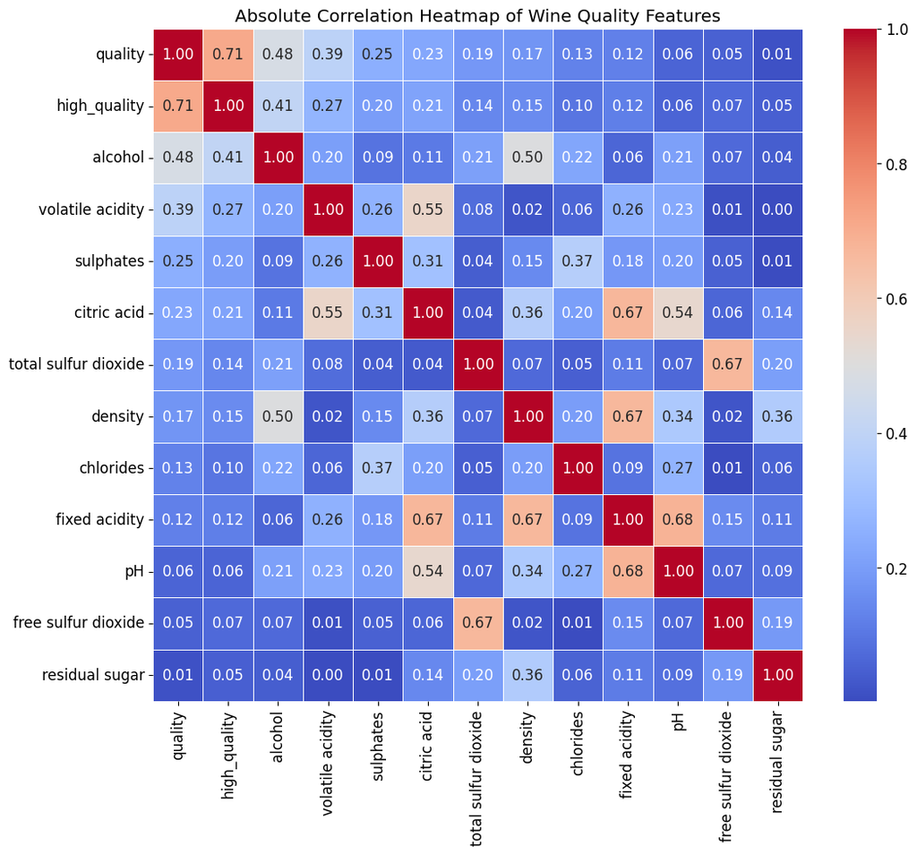

```python
# Compute correlation matrix (exclude color for Part 2)
corr_quality = red_wine.drop(columns=['color'], errors='ignore').corr(numeric_only=True)

# Convert correlations to absolute values
corr_quality_abs = corr_quality.abs()

# Sort features by absolute correlation with quality
sorted_features_q = corr_quality_abs['quality'].sort_values(ascending=False).index

# Reorder rows and columns
corr_quality_abs_sorted = corr_quality_abs.loc[sorted_features_q, sorted_features_q]

# Create heatmap
plt.figure(figsize=(12, 10))
sns.heatmap(
    corr_quality_abs_sorted,
    cmap='coolwarm',
    annot=True,
    fmt=".2f",
    linewidths=0.5
)

plt.title("Absolute Correlation Heatmap of Wine Quality Features")
plt.show()
```

**Interpretation**

- The strongest relationship with wine quality is observed for alcohol content. This suggests that wines with higher alcohol levels are more likely to receive higher quality ratings, making alcohol one of the most important predictors of wine quality.
- Volatile acidity shows a moderate relationship with quality. Higher volatile acidity is generally associated with lower quality wines, reflecting the negative impact of excessive acetic acid on taste. This reinforces its relevance as a key explanatory feature in quality prediction.

**Several features exhibit indirect influence through strong inter-feature relationships rather than direct correlation with quality. For example:**

- Density is strongly related to alcohol.
- Citric acid and volatile acidity show a strong inverse relationship.
- Fixed acidity and pH are strongly related, reflecting fundamental chemical balance.

These relationships suggest that while some features may not directly correlate strongly with quality, they still contribute useful information when combined in a multivariate model.

Features such as residual sugar, chlorides, free sulfur dioxide, and total sulfur dioxide show weak direct correlations with wine quality. This indicates that these variables alone are not strong predictors of quality but may still play a supporting role when interacting with other chemical properties.

Overall, the correlation analysis indicates that alcohol content and acidity related measures are the most informative features for predicting wine quality. At the same time, the presence of strong correlations among predictors suggests that a multivariate classification model, rather than single-feature analysis, is appropriate for this task.

### Part 3: Look into if it is better to create ratio features based on correlation

Based on the correlation analysis and exploratory plots, no additional ratio-based features are required at this stage of the analysis. The strongest relationships with wine quality are already captured by the original chemical measurements, particularly alcohol, volatile acidity, sulphates, and density.

# Predictive Modeling

**Part 1: Start with a classification model**

**Part 2: Train the model and make predictions**

### Part 1: Start with a classification model

### Part 2: Train the model and make predictions

Logistic regression is used as the classification model for predicting wine quality. This model is well suited for interpreting the relationship between individual chemical features and the probability of a wine being classified as high quality. Unlike decision trees, logistic regression provides coefficients that directly quantify feature influence.

```python
# Define features and target
X = red_wine.drop(columns=['quality', 'high_quality'])
y = red_wine['high_quality']

# Create train + validation and test split
X_temp, X_test, y_temp, y_test = train_test_split(
    X, y, test_size=0.2, random_state=42, stratify=y
)

# Create train and validation split
X_train, X_val, y_train, y_val = train_test_split(
    X_temp, y_temp, test_size=0.25, random_state=42, stratify=y_temp
)

# Pipeline: Scaling + Logistic Regression
pipe_logreg = Pipeline([
    ('scaler', StandardScaler()),
    ('logreg', LogisticRegression(max_iter=1000))
])

# Train the model
pipe_logreg.fit(X_train, y_train)

# Make predictions
y_train_pred = pipe_logreg.predict(X_train)
y_val_pred = pipe_logreg.predict(X_val)
y_test_pred = pipe_logreg.predict(X_test)

# Accuracy
print("Training Accuracy:", accuracy_score(y_train, y_train_pred))
print("Validation Accuracy:", accuracy_score(y_val, y_val_pred))
print("Test Accuracy:", accuracy_score(y_test, y_test_pred))
```

```
Training Accuracy: 0.8821689259645464
Validation Accuracy: 0.875
Test Accuracy: 0.8875
```

# Model Selection and Evaluation

**Part 1: Check the model performance, use a matrix to see the TP and FP**

**Part 2: Check for overfitting and Interpret the coefficients**

**Part 3: Use a classification report**

### Part 1: Check the model performance, use a matrix to see the TP and FP

After training the Logistic Regression model, its performance is evaluated using a confusion matrix. This allows examination of true positives, true negatives, false positives, and false negatives, rather than relying only on accuracy. This is especially important for classification problems, as accuracy alone does not show where misclassifications occur.

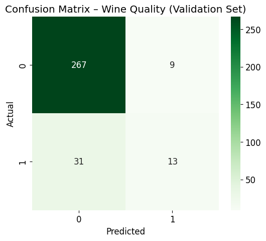

```python
# Confusion matrix for validation set
cm_q = confusion_matrix(y_val, y_val_pred)

plt.figure(figsize=(6, 5))
sns.heatmap(
    cm_q,
    annot=True,
    fmt='d',
    cmap='Greens'
)

plt.xlabel("Predicted")
plt.ylabel("Actual")
plt.title("Confusion Matrix – Wine Quality (Validation Set)")
plt.show()
```

The confusion matrix summarizes how well the logistic regression model predicts whether a red wine is classified as high quality (1) or not high quality (0).

The model performs well at identifying non high quality wines, with very few false positives. However, it is less effective at identifying high quality wines, as shown by the larger number of false negatives compared to true positives. This pattern is expected given that high quality wines are less common in the dataset.

Overall, the confusion matrix indicates that the model is reliable for ruling out high quality wines but may require threshold adjustments or additional feature exploration to improve detection of high quality cases.

### Part 2: Check for overfitting and Interpret the coefficients

To check for overfitting, training, validation, and test accuracy are compared again.

```python
# Check for overfitting by comparing accuracy across splits
print("Training Accuracy:", accuracy_score(y_train, y_train_pred))
print("Validation Accuracy:", accuracy_score(y_val, y_val_pred))
print("Test Accuracy:", accuracy_score(y_test, y_test_pred))
```

```
Training Accuracy: 0.8821689259645464
Validation Accuracy: 0.875
Test Accuracy: 0.8875
```

**Interpretation**

Overall, the logistic regression model demonstrates stable and reliable performance across all splits.

```python
# Extract coefficients from logistic regression model
coefficients = pd.Series(
    pipe_logreg.named_steps['logreg'].coef_[0],
    index=X.columns
).sort_values(key=abs, ascending=False)

coefficients
```

|  | 0 |
| --- | --- |
| alcohol | 0.962644 |
| total sulfur dioxide | -0.695133 |
| sulphates | 0.542123 |
| volatile acidity | -0.398892 |
| chlorides | -0.296582 |
| free sulfur dioxide | 0.267970 |
| density | -0.226296 |
| citric acid | 0.219301 |
| residual sugar | 0.213096 |
| fixed acidity | 0.159688 |
| pH | -0.113433 |
| color | 0.000000 |

**dtype:** float64

**Interpretation**

The logistic regression coefficients represent the direction and relative strength of each feature’s relationship with the probability of a wine being classified as high quality, holding all other features constant. Positive coefficients increase the likelihood of high quality, while negative coefficients decrease it.

**Most Influential Positive Features**

- Alcohol (0.96): Alcohol has the strongest positive relationship with high wine quality. Wines with higher alcohol content are substantially more likely to be classified as high quality.
- Sulphates (0.54): Higher sulphate levels are associated with an increased probability of high-quality wine, likely reflecting their role in wine stability and preservation.
- Free sulfur dioxide (0.27): Moderate positive contribution, suggesting some preservation-related benefit.

**Most Influential Negative Features**

- Total sulfur dioxide (−0.70): High total sulfur dioxide strongly decreases the likelihood of high quality, possibly due to adverse effects on flavor.
- Volatile acidity (−0.40): Higher volatile acidity is associated with lower wine quality, aligning with known sensory impacts.
- Chlorides (−0.30): Elevated chloride levels slightly reduce the probability of high-quality classification.
- Density (−0.23): Higher density is associated with lower quality, often reflecting lower alcohol or higher sugar content.

**Weaker Contributors**

- Citric acid, residual sugar, fixed acidity, and pH have relatively small coefficients, indicating weaker direct relationships with quality once other variables are controlled for.

The coefficient analysis reinforces the exploratory findings: alcohol content is the strongest positive indicator of high quality wine, while excessive sulfur compounds and volatile acidity are associated with lower quality. The model’s stable performance across data splits and interpretable coefficient structure indicate that logistic regression is an appropriate and effective method for predicting wine quality in this dataset.

### Part 3: Use a classification report

Accuracy alone can be misleading in classification problems, especially when the classes are imbalanced or when one class is easier to predict than the other. While overall accuracy summarizes how often the model is correct, it does not show how well the model performs for each class individually.

The classification report provides a more detailed evaluation by reporting precision, recall, and F1-score for each class:

- Precision measures how often predictions for a given class are correct.
- Recall measures how well the model identifies all actual observations of a class.
- F1-score balances precision and recall into a single metric.
- Support indicates how many observations belong to each class.

This breakdown is especially important for the wine quality task, where identifying high-quality wines may be more difficult due to class imbalance.

```python
print(classification_report(y_val, y_val_pred))
```

```
              precision    recall  f1-score   support

           0       0.90      0.97      0.93       276
           1       0.59      0.30      0.39        44

    accuracy                           0.88       320
   macro avg       0.74      0.63      0.66       320
weighted avg       0.85      0.88      0.86       320
```

**Interpretation of the Classification Report (Wine Quality)**

The classification report provides a detailed evaluation of the logistic regression model’s performance in predicting high quality wines (quality ≥ 7) versus lower quality wines.

**Class 0: Not High Quality**

- Precision (0.90): When the model predicts a wine is not high quality, it is correct 90% of the time.
- Recall (0.97): The model successfully identifies nearly all lower-quality wines.
- F1-score (0.93): Indicates strong and consistent performance for this class.

This suggests the model is very effective at recognizing wines that do not meet the high-quality threshold.

**Class 1: High Quality**

- Precision (0.59): When the model predicts a wine is high quality, it is correct 59% of the time.
- Recall (0.30): Only 30% of truly high-quality wines are correctly identified.
- F1-score (0.39): Indicates weaker performance for detecting high-quality wines.

This lower performance reflects the difficulty of predicting high-quality wines, which are less common in the dataset and share overlapping chemical characteristics with lower-quality wines.

**Overall Performance**

Accuracy (0.88): The model correctly classifies 88% of wines overall.

Macro average: Highlights the imbalance in performance between classes, showing weaker results for high-quality wines.

Weighted average: Remains high due to the larger number of lower-quality wines in the dataset.

The classification report shows that the logistic regression model performs well at identifying lower quality wines but struggles to correctly detect high quality wines. This imbalance is expected given the smaller number of high quality observations and the subjective nature of wine quality ratings. While overall accuracy is strong, recall for high quality wines remains limited, indicating that predicting exceptional wine quality is a more challenging task than predicting wine color in Part 1.

# Ethical Concerns and Limitations

**Try and find any biases in the data**

The following limitations primarily affect the wine quality prediction analysis:

- Subjectivity of Quality Scores: The quality variable is based on expert sensory evaluations. Although experts follow standardized rating procedures, quality scores remain subjective and may vary due to individual palate differences, experience, or contextual factors. This introduces noise into the target variable.
- Binary Quality Thresholding: Converting the original quality score into a binary high-quality indicator (e.g., quality ≥ 7) simplifies interpretation but may remove meaningful distinctions between moderate and high-quality wines.
- Imbalanced Quality Classes: High quality wines represent a smaller proportion of the dataset, particularly in the red wine subset. This imbalance can make it more difficult for the model to correctly identify high-quality wines, as reflected in lower recall for the positive class.
- Limited Sensory Representation: All predictors are chemical measurements and do not capture sensory attributes such as aroma, mouthfeel, or consumer preference. As a result, the model reflects chemical predictors of expert ratings rather than holistic wine quality perception.

# Final Summary: Part 2 Predicting Wine Quality

This section focuses on identifying the chemical characteristics that distinguish high quality wines from lower quality wines. Using exploratory data analysis, correlation analysis, and logistic regression modeling, the relationship between chemical features and wine quality is examined. The results from this analysis are used to answer the remaining research questions related to wine quality.

### 3. Does color have an effect on the quality of the wine?

Wine color alone does not appear to be a strong determinant of wine quality. Exploratory analysis shows that the distribution of quality scores overlaps substantially between red and white wines, indicating that high and low quality wines exist within both color categories.

While red and white wines differ chemically, quality variation within each color group is large. This suggests that wine quality is driven more by specific chemical characteristics than by color itself, supporting the decision to model quality separately rather than relying on wine color as a primary predictor.

### 4. What features best determine what the quality of the wine is?

The analysis shows that several chemical features are strongly associated with whether a wine is classified as high quality. Based on box plots, scatter plots, correlation analysis, and logistic regression coefficients, the most influential features include:

`Alcohol`: Alcohol shows the strongest positive relationship with wine quality. Higher quality wines consistently have higher alcohol content, and logistic regression coefficients indicate that increases in alcohol substantially raise the likelihood of a wine being classified as high quality.

`Sulphates`: Sulphates display higher median values among high quality wines and show a positive association with quality. This suggests that sulphates, which contribute to wine stability and flavor perception, play an important role in quality evaluation.

`Volatile acidity`: Volatile acidity is negatively associated with wine quality. High quality wines tend to have lower volatile acidity, while lower quality wines exhibit higher values. This aligns with known wine chemistry, as excessive volatile acidity can lead to undesirable flavors.

Overall, wine quality is most strongly determined by alcohol content, sulphates, and acidity-related features, rather than by wine color. These results indicate that expert quality ratings are closely tied to measurable chemical composition rather than broad categorical distinctions.

```python
%%capture
# Convert this notebook to HTML
! jupyter nbconvert --to html --no-prompt "/content/drive/My Drive/Math237Fall25/Notebooks/Chatton_Amber_Project_2.ipynb"  --output project.2.final
```